[figure not shown]

Introducción al Muestreo - Semana 13

Carlos M. Lopera-Gómez, Ph.D

cmlopera@unal.edu.co

Profesor Asociado - Escuela de Estadística

Universidad Nacional de Colombia, Sede Medellín

Semestre 2023-2S

[figure not shown]

Muestreo aleatorio simple estratiﬁcado sin reemplazo

(MAE)

El MAS sólo es apropiado cuando la población de la cual se

muestrea puede considerarse homogénea, es decir, cuando la

distribución de valores de la variable de interés no depende de

ciertas características de las unidades o elementos de la población.

Por el contrario, si la distribución de valores de una variable depende

de ciertas características que crean subgrupos poblacionales

disjuntos previamente identiﬁcados, en ese caso, un MAS conllevaría

a estimaciones menos precisas y no representativas para todos los

subgrupos poblacionales.

[figure not shown]

Los subgrupos poblacionales disjuntos reciben el nombre de estratos.

Los estratos pueden establecerse de acuerdo a variables cualitativas

o cuantitativas sobre las cuales se posee suﬁciente información, por

ejemplo, variables geográﬁcas, demográﬁcas, socio-económicas,

tecnológicas, entre otras.

Los estratos en muestreo deben cumplir:

Homogeneidad que debe existir dentro de los estratos.

Heterogeneidad entre los estratos.

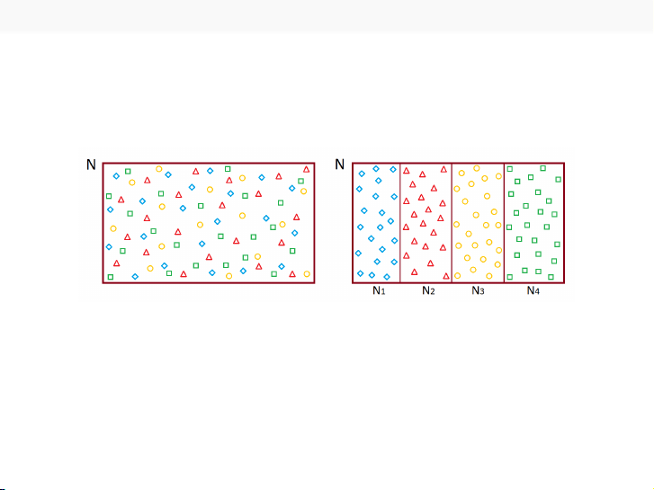

Ilustración del MAE

Esto conlleva a mejorar la precisión de los estimadores y a minimizar

costos en la recolección de la información.

[figure not shown]

Sintetizando, las razones por las cuales se recurre al MAE son (Lohr,

2001):

Para protegernos contra la posibilidad de obtener una mala

muestra.

Para obtener datos de precisión sobre subgrupos o estratos.

Para mayor eﬁciencia en la administración y reducción de

costos. Se pueden usar distintos esquemas de muestreo para

diversos estratos.

Si se hace correctamente, se obtienen estimaciones más

precisas para toda la población.

[figure not shown]

Recordar que es condición necesaria para una buena estratiﬁcación

que

Los elementos individuales dentro de cada estrato deben tener

cierta homogeneidad pero las medias de los estratos deberán

diferir entre sí lo más posible.

No se deben presentar traslapes entre estratos y todos juntos

deberán formar la población completa.

[figure not shown]

Idea básica del MAE

El procedimiento aplicado en este diseño muestral consiste en

considerar a los estratos como subpoblaciones independientes.

Suponga que la población está dividida en Lestratos y que en cada

uno podemos deﬁnir los parámetros siguientes, con i=1,2,...,L

(todas las variables y parámetros usados en relación a los estratos

tendrán subíndice i):

Ni: corresponde al tamaño del i-ésimo estrato.

N=L

P

i=1

Ni: es el tamaño de la población.

yij : es el valor de la variable de interés en la j-ésima unidad o

elemento del i-ésimo estrato.

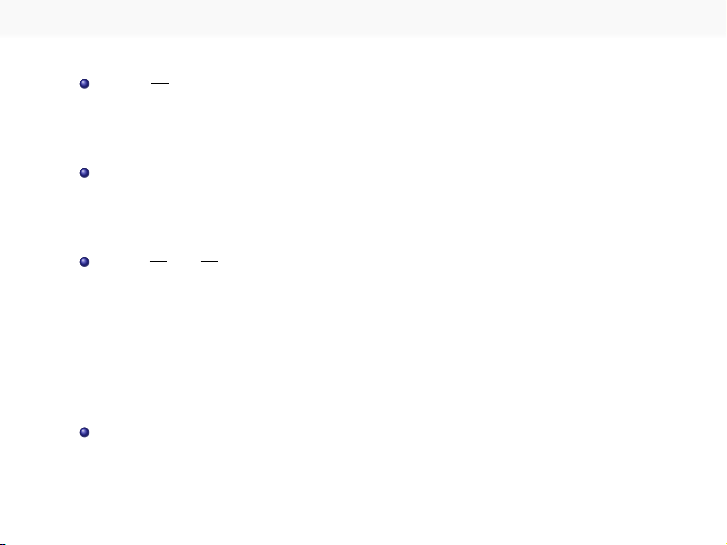

µi=1

Ni

Ni

P

j=1

yij : es la media poblacional de una variable de

interés cuantitativa Yen el i-ésimo estrato.

τi=

Ni

P

j=1

yij =Niµi: es el total poblacional una variable de

interés cuantitativa Yen el i-ésimo estrato.

pi=Ai

Ni=1

Ni

Ni

P

j=1

yij : es la proporción de elementos o unidades

de la población que poseen una característica dada en el

i-ésimo estrato. Acá yij es el valor de una variable indicadora

de si la j-ésima unidad o elemento del i-ésimo estrato posee

una característica dada.

Ai=

Ni

P

j=1

yij =Nipi: es el total de elementos o unidades de la

población que poseen una característica dada en el i-ésimo

estrato.

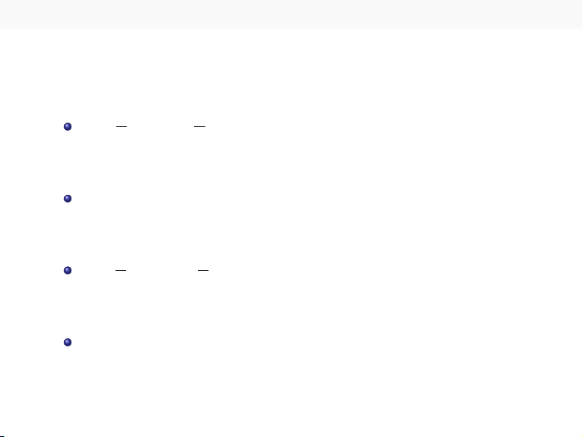

Luego, los parámetros poblacionales globales en función de los

parámetros poblacionales de cada estrato, están dados por:

µ

=

1

N

L

P

i=1

τi

=

1

N

L

P

i=1

N

iµi

: es la media global de la variable de

interés en la población.

τ

=

L

P

i=1

τi

=

L

P

i=1

N

iµi

: es el total global de la variable de interés

en la población. También se cumple que τ=Nµ.

p=1

N

L

P

i=1

Ai=1

N

L

P

i=1

Nipi: es la proporción global de

individuos que en la población poseen cierta característica.

A=L

P

i=1

Ai=L

P

i=1

Nipi: es el número total global de individuos

en la población que poseen cierta característica. También se

[figure not shown]

Para efectos de muestreo y estimación se procede de la siguiente

manera:

1Se determina el tamaño global de muestra n.

2

Se determinan los tamaños de muestra en cada estrato, n

i

, tal

que n=L

P

i=1

ni.

3

De cada estrato se toma una MAS sin reemplazo de tamaño n

i

.

4Se obtienen las estimaciones de los parámetros de interés en

cada estrato.

5

Se combinan las estimaciones de los parámetros de interés para

generar la estimación puntual global del parámetro en la

población.

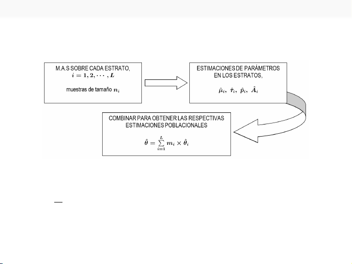

La siguiente ﬁgura esquematiza el procedimiento de muestreo y

estimación en MAE.

Note que, de las expresiones de los parámetros poblacionales

globales en función de los parámetros poblacionales de cada estrato,

mi=Ni

Npara µyp, y mi=1 para τyA.

Además, Vb

θ=V L

P

i=1

mib

θi!=L

P

i=1

Vmib

θi=L

P

i=1

m2

iVb

θi.

[figure not shown]

Estimaciones

Para estimar los parámetros de interés en cada estrato, se aplican

las fórmulas correspondientes al MAS sin reemplazo.

Las estimaciones en los estratos se combinan para obtener una

estimación global.

Las medias y proporciones poblacionales globales son básicamente

promedios ponderados, en los que el factor de peso es Ni/N.

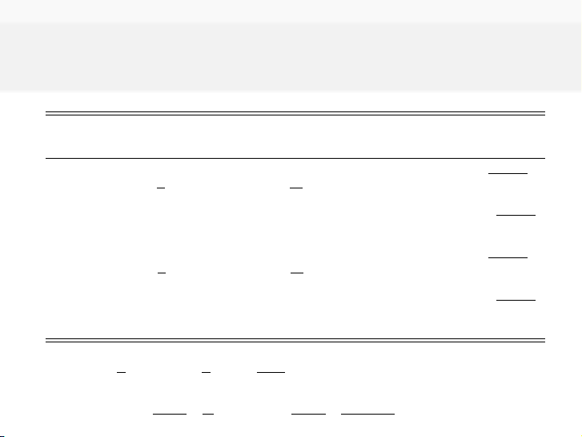

Estimadores e intervalos de conﬁanza poblacionales

en MAE

Parámetro Estimador Varianza estimada Intervalo de conﬁanza

a estimar puntual del estimador del (1−α)100%

µ¯

Yst =1

N

L

P

i=1

Ni¯

YibV¯

Yst=1

N2

L

P

i=1

N2

ibV¯

Yi¯

Yst ±tα/2,n−LqbV¯

Yst

τbτst =N¯

Yst =

L

P

YstN¯

Yst ±tα/2,n−LNqbV¯

Yst

pbpst =1

N

L

P

i=1

NibpibVbpst=1

N2

L

P

i=1

N2

AbAst =Nbpst =

L

P

Donde: ¯

Yi=1

ni

ni

P

j=1

Yij ,bpi=ai

ni

,S2

i=1

ni−1

ni

P

j=1Yij −¯

L

P

i=1

(ni−1)

bV¯

Yi=Ni−ni

NiS2

i

ni

,bVbpi=Ni−ni

Nibpi1−bpi

ni−1

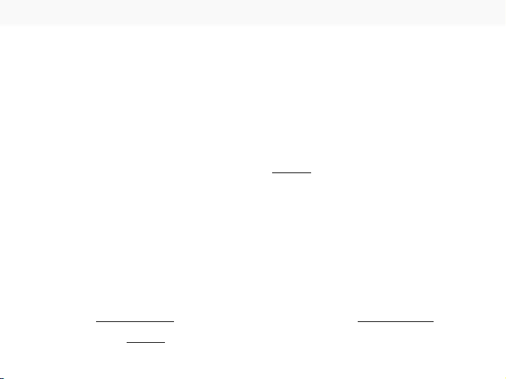

Los intervalos de conﬁanza especiﬁcados son apropiados si los

tamaños de muestras en los estratos, ni, son suﬁcientemente

grandes para aplicar la aproximación normal. De lo contrario, las

estimaciones de las varianzas tienden a ser inestables. Como

solución, se ha propuesto aplicar una aproximación Satterthwaite

para los grados de libertad de la distribución t. Esta aproximación

implica que los intervalos de conﬁanza se calculen como:

b

θ±tα/2,ν rb

Vb

θ

donde los grados de libertad ν, por la aproximación Satterthwaite

corresponden a:

ν= L

P

i=1

kiS2

i!2

L

P

i=1

(kiS2

i)2

ni−1

,con las constantes ki=Ni(Ni−ni)

ni

.

[figure not shown]

Tamaños de muestra en MAE para la estimación de

medias y totales poblacionales

En cuanto a los tamaños de muestra, en este diseño muestral es

necesario:

1Cálculo del tamaño de muestra global n, es decir el total de

unidades o elementos que se muestrearán de toda la población.

2

Aﬁjación de la muestra, lo cual responde a la pregunta dado un

tamaño de muestra total n, ¿cómo distribuirlo entre los

estratos?, es decir, ¿cómo calcular los tamaños de muestra para

cada estrato (los ni’s)?

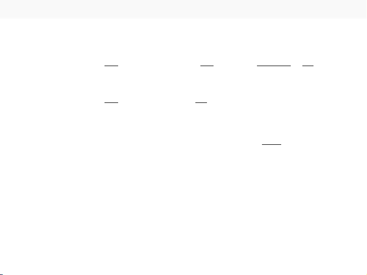

Para el estimador de una media poblacional µse tiene que:

V¯

Yst=1

N2

L

X

i=1

N2

iV¯

Yi=1

N2

L

X

i=1

N2

iNi−ni

Nie

σ2

i

ni

=1

N2

L

X

i=1

Ni(Ni−ni)e

σ2

i

ni

Lo cual implica que: N2V¯

Yst+L

P

i=1

Nie

σ2

i=L

P

i=1

N2

ieσ2

i

ni.

Note que en la expresión no aparece n, pero sabemos que

PL

i=1

n

i

=n, por lo tanto los tamaños de muestra en los estratos se

pueden representar como n

i

=

ψi

n, donde

ψi

es llamada la fracción

de aﬁjación de la muestra de tamaño npara el estrato i, y cumple

que 0 ≤ψi≤1 y PL

i=1ψi=1.

Reemplazando nipor ψiny asumiendo e

σ2

i≈σ2

i, se obtiene el

siguiente resultado.

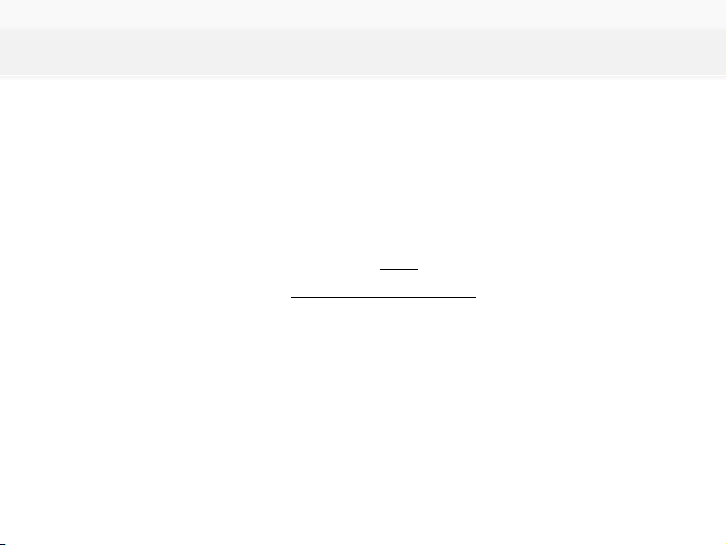

Determinación del tamaño de la muestra total

El tamaño de muestra aproximado para estimar

µ

ó

τ

para un valor

preﬁjado para la varianza del respectivo estimador es dada por la

siguiente ecuación:

n=

L

P

i=1

N2

iσ2

i

ψi

N2Vb

θ+L

P

i=1

Niσ2

i

con b

θigual a b

µ=¯

Yst ob

τst, respectivamente. Como en el caso de

MAS, estas varianzas deben ser pre estimadas para poder calcular

los tamaños de muestra.

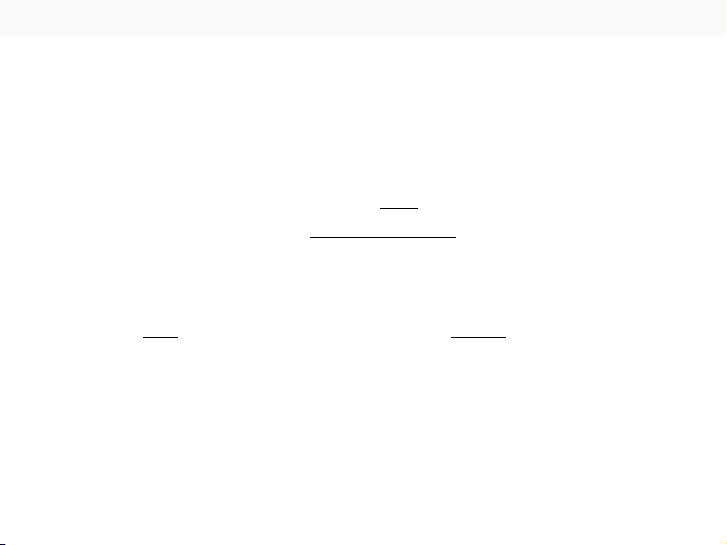

Cuando se impone un límite para el error de estimación δ, con un

nivel de conﬁanza del (1−α)100%, la ecuación anterior toma la

siguiente forma:

n=

L

P

i=1

N2

iσ2

i

ψi

N2D+L

P

i=1

Niσ2

i

(*)

con D=

δ2

Z2

α/2

cuando se estima a

µ

yD=

δ2

N2Z2

α/2

cuando se estima

aτ.

A continuación se deﬁnen los criterios de aﬁjación los cuáles

determinan los valores de los ψien las ecuaciones anteriores.

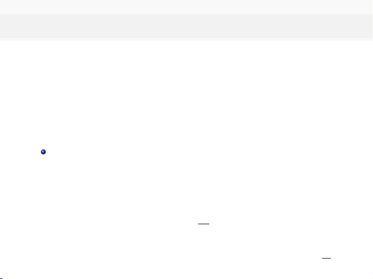

Aﬁjación de la muestra en los estratos

Respecto a la aﬁjación, básicamente existen tres formas, que

dependen de la información que se conozca y de lo que se desea

minimizar. A continuación, se presentan los métodos de aﬁjación

para la estimación de medias y totales poblacionales (en las

siguientes ecuaciones, en general,

σi

se reemplaza por su estimación

previa S∗

i):

Aﬁjación proporcional: si no tenemos información alguna

sobre costos de muestreo ni sobre las varianzas de la variable

respuesta en cada estrato, lo más que podemos hacer es

asignar los tamaños de muestra proporcionalmente al tamaño

de los estratos:

ni=Ni

Nn.

Observe que en este caso la fracción de aﬁjación es ψi=Ni

N.

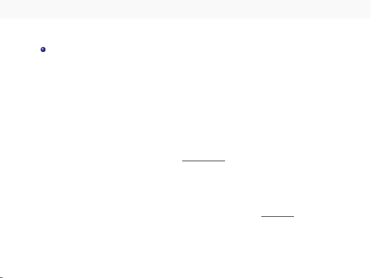

Aﬁjación de Neyman: si conocemos las varianzas de los

estratos σ2

i(aunque no los costos de ninguna índole o

asumimos que son iguales), podemos minimizar la varianza del

estimador (de la media o del total poblacional) sujetos a que

L

P

i=1

ni=ncon el siguiente valor de ni(para demostrarlo hay

que usar multiplicadores de Lagrange):

ni=Niσi

L

P

k=1

Nkσk

n.

En este caso la fracción de aﬁjación es ψi=Niσi

L

P

k=1

Nkσk

.

[figure not shown]

Aﬁjación óptima para costos variables: Cuando se conocen

los costos ﬁjos totales C

0

y se conoce C

i

el costo por unidad del

estudio de muestreo en el estrato io se tiene un presupuesto

de antemano preﬁjado, estamos ante una restricción. Suponga

que también son conocidas las varianzas de la variable de

interés en cada estrato, entonces debemos buscar cómo asignar

el tamaño global de muestra nde modo que se garantice la

menor variabilidad del estimador para los costos ﬁjos o que

minimice los costos totales para la varianza preﬁjada para el

estimador, donde el costo del muestreo es dado por,

Costo de muestreo con restricción presupuestal:

L

P

i=1

niCi=C−C0.

Costo de muestreo sin restricción presupuestal: L

P

i=1

niCi.

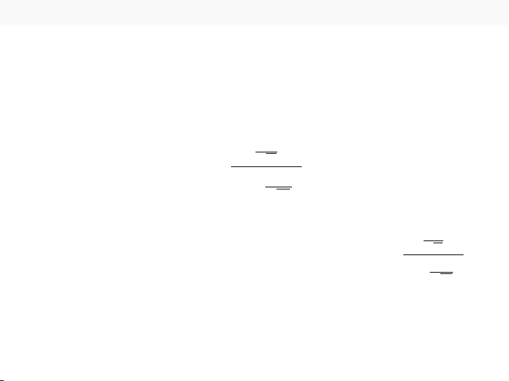

Luego, la aﬁjación óptima para minimizar la varianza del estimador

de la media poblacional, sujetos al presupuesto dado, o para

minimizar el costo total sujetos a un valor preﬁjado (deseado) para

la varianza del estimador (para obtener la fórmula hay que usar

multiplicadores de Lagrange) corresponde a:

ni=

Niσi

√Ci

L

P

k=1Nkσk

√Ckn

En este caso la fracción de aﬁjación corresponde a ψi=

Niσi

√Ci

L

P

k=1Nkσk

√Ck.

A continuación se deﬁnen diferentes fórmulas de tamaño de muestra

según la información conocida y objetivos (minimización de varianza

del estimador de la media y/o de los costos de muestreo) y usando

el criterio de aﬁjación apropiado.

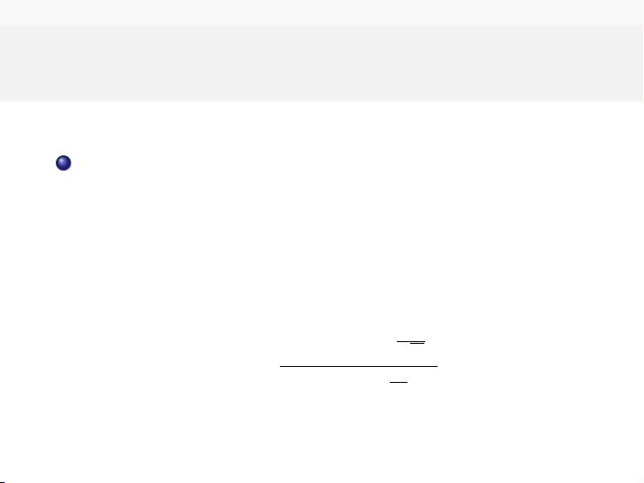

Determinación de npara estimación de la media

poblacional µ

Sea Ciel costo unitario de muestreo en el estrato i.

a) Para minimizar V¯

Ysty sujetos a la restricción de un

presupuesto para el cual el costo total es C=C

0

+

L

P

i=1

n

i

C

i

, es

decir, C

−

C

0

ya está ﬁjado y es el presupuesto disponible para

la recolección de la información en los estratos (se aplican

multiplicadores de Lagrange):

n=

(C−C0)L

P

i=1Nieσi

√Ci

L

P

i=1Nie

σi√Ci

Para hallar los nise debe usar aﬁjación óptima para costos

variables.

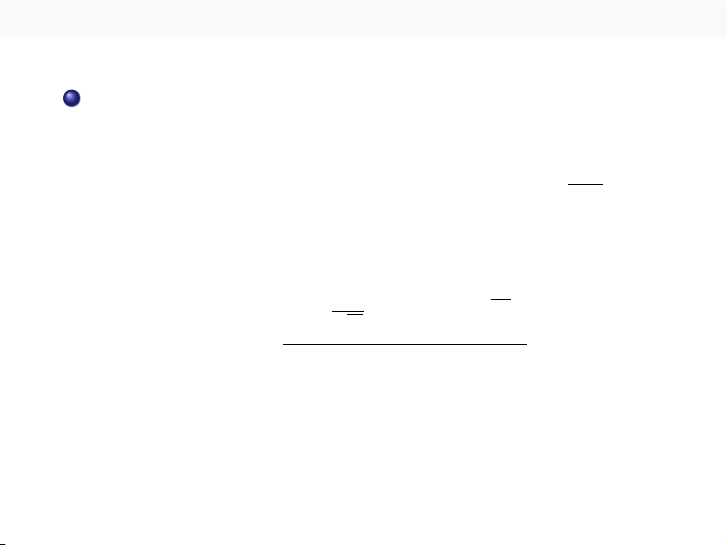

b) Para minimizar los costos totales (no se conocen los costos

ﬁjos, sólo los costos variables y no se tiene preﬁjado el valor de

C, y por tanto no estamos limitados por un presupuesto) para

un valor de V¯

Ystpreviamente preﬁjada en D=δ2

Z2

α/2

, se

reemplaza ψipor la correspondiente aﬁjación óptima para

costos variables en la ecuación (*), llegando a:

n= L

P

i=1

Nieσi

√Ci! L

P

i=1

Nie

σi√Ci!

N2D+L

P

i=1

Nie

σ2

i

Para hallar los nise debe usar nuevamente la aﬁjación óptima

para costos variables.

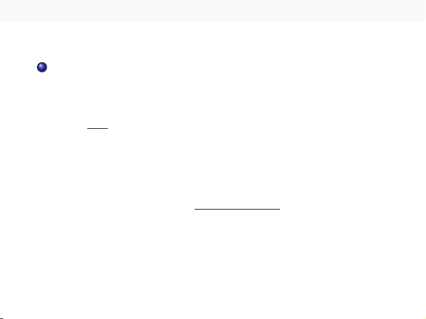

c) Para minimizar V¯

Yst, sujetos a la condición L

P

i=1

ni=n, sin

información sobre costos de ninguna índole, pero se conoce la

varianza dentro de los estratos, para V¯

Ystpreﬁjada en

D=δ2

Z2

α/2

, se reemplaza ψipor la correspondiente aﬁjación de

Neyman en la ecuación (*), llegando a:

n= L

P

i=1

Nie

σi!2

N2D+L

P

i=1

Nie

σ2

i

Para hallar los n

i

de nuevo se debe usar la aﬁjación de Neyman.

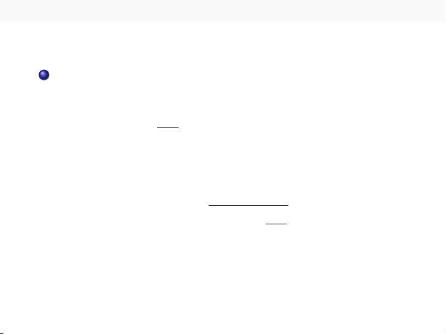

d) Cuando desconocemos costos y no estamos seguros de que

valores asignar a las varianzas dentro de los estratos (aunque si

se requieren las estimaciones previas e

S∗2

i), se puede preﬁjar

V

¯

Yst

en D=

δ2

Z2

α/2

, y se reemplaza

ψi

por la correspondiente

aﬁjación proporcional en la ecuación (*), llegando a:

n=

L

P

i=1

Nie

σ2

i

ND +L

P

i=1

Nieσ2

i

N

Para hallar los ninuevamente se usa la aﬁjación proporcional.

[figure not shown]

El procedimiento a seguir

1

Determinar primero nsin aproximarlo a ningún entero (es decir

tomarlo con cifras decimales).

2

Si se tienen restricciones de costos, se determinan los n

i

con el

método de aﬁjación apropiado, redondeándolos al entero más

próximo. En caso contrario, se recomienda usar la aproximación

al entero siguiente.

3Si se tienen restricciones de costos: se debe comprobar que

L

X

i=1

ni,redondeado =nredondeado.

En caso contrario, se actualiza el valor del tamaño de muestra

an=L

P

i=1

ni,redondeado.

[figure not shown]

4En en caso de tener restricciones de costos si la anterior

condición no se cumple por defecto (es decir es menor que el

valor de nredondeado), aumentar el tamaño de muestra para

aquel estrato (o estratos) con la cantidad no entera (decimal)

más grande antes del redondeo. Si la condición no es cumplida

por exceso, tomar la parte entera como tamaño de muestra

para aquel estrato que originalmente tiene la mayor parte

decimal.

5

Si se tienen restricciones presupuestales, además de comprobar

L

P

i=1

ni,redondeado =nredondeado, se debe veriﬁcar que:

L

P

i=1

Cini,redondeado =C−C0.

Si no se cumple, modiﬁcar los ni, de modo que se cumplan

ambas condiciones, o como mínimo esta última.

[figure not shown]

Tamaños de muestra en MAE para la estimación de

proporciones y totales de individuos con cierta

característica

Por MAS sin reemplazo en cada estrato se conocen las varianzas

para las proporciones estimadas en los estratos, y globalmente

considerando la independencia de los estimadores entre estratos en

toda la población.

Para las siguientes fórmulas, se asume que las observaciones y

ij

son

variables Bernoulli (es decir, tomando sólo valores de 0 ó 1) así que

µi=piy las varianzas en los estratos corresponden a

σ2

i=pi(1−pi).

Luego, podemos usar las ecuaciones vistas en el caso de la media de

una variable cuantitativa.

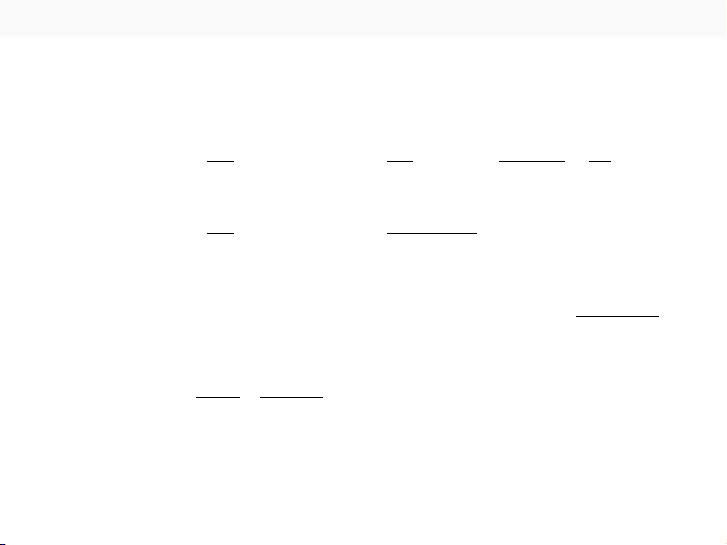

Para el estimador de una proporción poblacional pse tiene que:

V(b

pst) = 1

N2

L

X

i=1

N2

iV(b

pi) = 1

N2

L

X

i=1

N2

iNi−ni

Nie

σ2

i

ni

=1

N2

L

X

i=1

Ni(Ni−ni)pi(1−pi)

ni

Lo cual implica que: N2V(b

pst) + L

P

i=1

Nipi(1−pi) = L

P

i=1

N2

ipi(1−pi)

ni.

La fórmula anterior supone que los estratos son grandes, de manera

que V(b

pi)≈Ni−ni

Nipi(1−pi)

ni.

Como en el caso cuantitativo, se reemplaza n

i

por

ψi

n, obteniendo

lo siguiente.

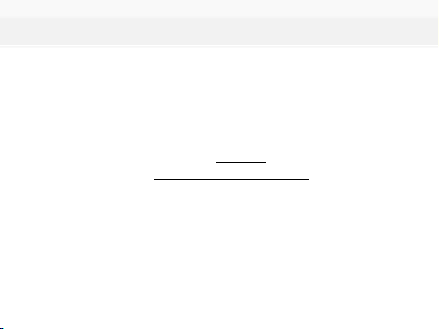

Determinación del tamaño de la muestra total

El tamaño de muestra aproximado para estimar ppara un valor

preﬁjado para la varianza del respectivo estimador V(b

pst), es dado

por la siguiente ecuación:

n=

L

P

i=1

N2

ipi(1−pi)

ψi

N2Vb

θ+L

P

i=1

Nipi(1−pi)

con

b

θ

igual a

b

pst

o

b

Ast

, respectivamente. Como en el caso de MAS,

los valores desconocidos p

i

se deben pre estimar para poder calcular

los tamaños de muestra.

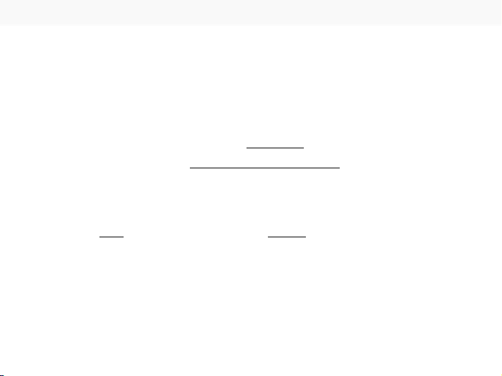

Cuando se impone un límite para el error de estimación δcon un

nivel de conﬁanza del 95%, la ecuación anterior toma la siguiente

forma

n=

L

P

i=1

N2

ipi(1−pi)

ψi

N2D+L

P

i=1

Nipi(1−pi)

(**)

con D=δ2

Z2

α/2

al estimar a pyD=δ2

N2Z2

α/2

al estimar a A.

A continuación se deﬁnen los criterios de aﬁjación los cuáles

determinan los valores de los ψien las ecuaciones anteriores.

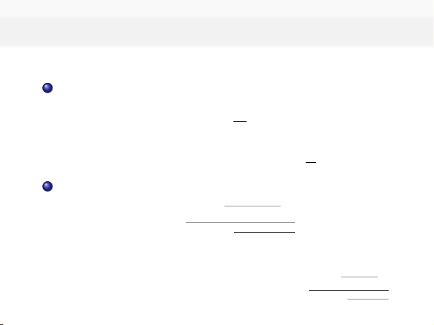

Aﬁjación de la muestra en los estratos.

Las aﬁjaciones en este caso se calculan como sigue:

1Aﬁjación proporcional:

ni=Ni

Nn

En este caso la fracción de aﬁjación es ψi=Ni

N.

2Aﬁjación de Neyman:

ni≈Nippi(1−pi)

L

P

k=1

Nkppk(1−pk)

n

En este caso, la fracción de aﬁjación es ψi=Ni√pi(1−pi)

L

P

k=1

Nk√pk(1−pk)

.

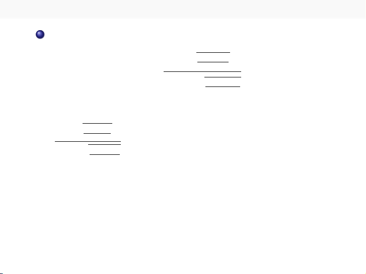

3Aﬁjación óptima para costos variables:

ni≈Niqpi(1−pi)

Ci

L

P

k=1

Nkqpk(1−pk)

Ck

n

La fracción de aﬁjación en este caso corresponde a

ψi=Niqpi(1−pi)

Ci

L

P

k=1

Nkqpk(1−pk)

Ck

.

Para los cálculos de ny los nise sigue el procedimiento descrito

previamente en el caso cuantitativo.

A continuación se deﬁnen diferentes fórmulas de tamaño de muestra

según la información conocida y objetivos (minimización de varianza

del estimador de la proporción y/o de los costos de muestreo) y

usando el criterio de aﬁjación apropiado.

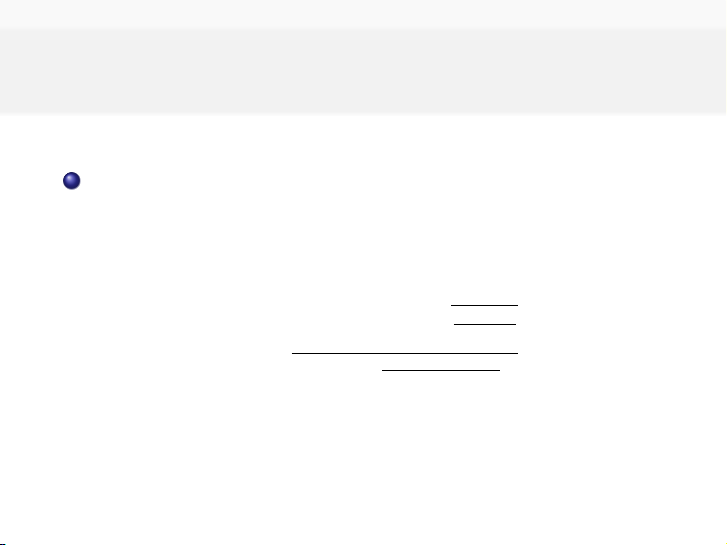

Determinación de

n

para estimación de la proporción

poblacional p

a) Para minimizar V(b

pst)sujeto a la restricción de un

presupuesto, es decir, C−C0ya está dado y corresponde al

presupuesto para la recolección de la información en los

estratos (se aplican multiplicadores de Lagrange):

n=

(C−C0)L

P

i=1

Niqpi(1−pi)

Ci

L

P

i=1

Nippi(1−pi)Ci

Para hallar los nise debe usar la aﬁjación óptima para costos

variables, en el caso de proporciones.

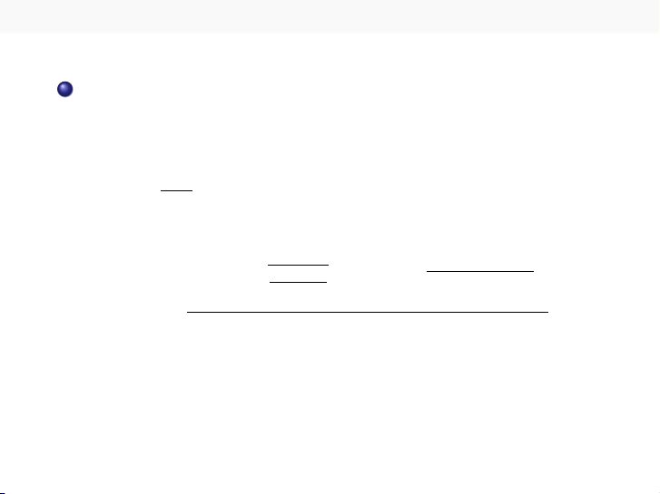

b) Cuando queremos minimizar los costos totales (no se conocen

los costos ﬁjos, sólo los costos variables y no se tiene preﬁjado

el valor de C, y por tanto no estamos limitados por un

presupuesto) sujetos a un valor de V(b

pst)previamente ﬁjado

en D=δ2

Z2

α/2

n= L

P

i=1

Niqpi(1−pi)

Ci! L

P

i=1

Nippi(1−pi)Ci!

N2D+L

P

i=1

Nipi(1−pi)

Para el cálculo de los ninuevamente se debe usar la aﬁjación

óptima para costos variables, en el caso de proporciones.

[figure not shown]

P

i=1

ni=n, y no conocemos costos de ninguna índole, pero si

tenemos información sobre las proporciones de los estratos,

para V(b

pst)preﬁjada en D=δ2

Z2

α/2

, se reemplaza ψipor la

P

i=1

P

i=1

Nipi(1−pi)

Para el cálculo de los nise usa de nuevo la aﬁjación de

Neyman, en el caso de proporciones.

[figure not shown]

d) Cuando desconocemos los costos y la homogeneidad en cada

estrato, lo único que podemos hacer es preﬁjar V(b

pst)en

D=δ2

Z2

α/2

, y se reemplaza ψipor la correspondiente aﬁjación

proporcional en la ecuación (**), llegando a:

P

i=1

Nipi(1−pi)

N

L

P

i=1

Nipi(1−pi)

Para el cálculo de los nide nuevo se debe usar la aﬁjación

proporcional.

[figure not shown]

Pesos de muestreo

Considere el estimador del total de una variable

τst =

L

X

i=1

Ni¯

Yi.

Podemos rescribir esta fórmula de la siguiente manera:

τst =

L

X

i=1

Ni

ni

X

j=1

Yij

ni

=

L

X

i=1

ni

X

j=1

Ni

ni

Yij =

L

X

i=1

ni

X

j=1

ωij Yij

donde el subíndice jes para las unidades seleccionadas en cada

estrato para la muestra.

[figure not shown]

El peso de muestreo corresponde a la constante

ωij

n

i

y puede

interpretarse como el número de unidades en la población

representadas por el miembro i,jde la muestra.

Ejemplo: si la población tiene 1600 hombres y 400 mujeres, y el

diseño muestral estratiﬁcado especiﬁca una muestra de 200 hombre

y 200 mujeres, entonces cada hombre de la muestra tiene un peso

de 8 y por tanto se representa a sí mismo y a otros 7 hombres que

no están en la muestra, en tanto que cada mujer de la muestra tiene

un peso de 2 y por tanto se representa así misma y a otra mujer que

no está en la muestra (Lohr, 2001).

[figure not shown]

La probabilidad de elegir la unidad jdel estrato ipara estar en la

muestra es

πij

N

i

, la fracción de muestreo en el estrato i. Por

tanto el peso de muestreo es el inverso de esta probabilidad.

La suma de los pesos de muestreo es igual al tamaño de toda la

población N, es decir

P

i=1

ni

P

j=1

ωij

=N, esto es cierto dado que como

cada unidad de la muestra representa a cierta cantidad de unidades

de la población, entonces la muestra completa representa a toda la

población. La estimación de la media poblacional haciendo uso de

los pesos de muestreo corresponde por tanto a:

Yst =b

τst

N=

L

P

i=1

ni

P

j=1

ωij Yij

L

P

j=1ωij